# WORKSHOP2024_3: Paired DE analysis

# A. Load libraries

Load required R packages

```r
pacman::p_load(BiocManager, DESeq2, readxl, tidyverse, pheatmap, ashr)
```

# B. Load read counts table

```r
# Load raw read counts
counts.raw <- read.delim(file = "data/counts_ex1_2t.txt",
                         header = T, sep = "\t",row.names = 1)

counts.raw
```

|  | A_M0 | A_M4 | B_M0 | B_M4 | C_M0 | C_M4 | D_M0 | D_M4 | E_M0 | E_M4 | G_M0 | G_M4 | I_M0 | I_M4 | K_M0 | K_M4 | L_M0 | L_M4 | N_M0 | N_M4 | O_M0 | O_M4 | P_M0 | P_M4 |
| --- | --- | --- | --- | --- | --- | --- | --- | --- | --- | --- | --- | --- | --- | --- | --- | --- | --- | --- | --- | --- | --- | --- | --- | --- |
| ENSG00000223972 | 84 | 27 | 9 | 13 | 59 | 46 | 55 | 32 | 48 | 25 | 38 | 33 | 50 | 32 | 10 | 15 | 54 | 27 | 18 | 5 | 54 | 16 | 22 | 11 |
| ENSG00000227232 | 539 | 583 | 887 | 1104 | 439 | 695 | 676 | 391 | 952 | 594 | 422 | 236 | 711 | 994 | 670 | 2455 | 817 | 949 | 784 | 1106 | 1125 | 776 | 913 | 1153 |
| ENSG00000278267 | 37 | 49 | 49 | 89 | 21 | 48 | 44 | 26 | 68 | 54 | 35 | 15 | 47 | 58 | 38 | 99 | 76 | 64 | 44 | 60 | 79 | 46 | 61 | 67 |
| ENSG00000243485 | 0 | 0 | 0 | 1 | 1 | 0 | 0 | 1 | 1 | 2 | 0 | 0 | 0 | 0 | 0 | 4 | 0 | 0 | 0 | 1 | 0 | 0 | 0 | 1 |
| ENSG00000274890 | 0 | 0 | 0 | 0 | 0 | 0 | 0 | 0 | 0 | 0 | 0 | 0 | 0 | 0 | 0 | 0 | 0 | 0 | 0 | 0 | 0 | 0 | 0 | 0 |
| ENSG00000237613 | 3 | 2 | 1 | 0 | 1 | 0 | 0 | 0 | 2 | 0 | 0 | 1 | 0 | 0 | 1 | 1 | 0 | 0 | 1 | 0 | 0 | 2 | 0 | 0 |
| ENSG00000268020 | 0 | 0 | 0 | 0 | 0 | 0 | 0 | 0 | 0 | 0 | 0 | 0 | 0 | 0 | 0 | 0 | 0 | 0 | 0 | 0 | 0 | 0 | 0 | 0 |
| ENSG00000240361 | 0 | 0 | 0 | 0 | 0 | 0 | 0 | 0 | 0 | 0 | 0 | 0 | 0 | 0 | 0 | 0 | 0 | 0 | 0 | 1 | 0 | 0 | 0 | 0 |
| ENSG00000186092 | 0 | 0 | 0 | 0 | 0 | 0 | 0 | 0 | 0 | 0 | 0 | 0 | 0 | 0 | 0 | 0 | 0 | 0 | 0 | 0 | 0 | 0 | 0 | 0 |
| ENSG00000238009 | 24 | 31 | 20 | 25 | 18 | 36 | 63 | 35 | 30 | 31 | 33 | 17 | 59 | 62 | 90 | 66 | 62 | 76 | 16 | 51 | 48 | 51 | 63 | 55 |

[output cut: 990 more lines]

# C. Load metadata

```r
summary(metadata)
```

```
   Genotype      Sbj_id    Treatment  Sbj_alt   read_counts
 Geno_1:12   A      : 2   Before:12   SbjA:4   Min.   :15160631
 Geno_2:12   B      : 2   After :12   SbjB:4   1st Qu.:19349665
             C      : 2               SbjC:4   Median :23331349
             D      : 2               SbjD:4   Mean   :23968537
             E      : 2               SbjE:4   3rd Qu.:26346885
             G      : 2               SbjG:4   Max.   :36748965
             (Other):12
```

# D. Clean gene expression data

## 1. Filter genes based on read counts per sample

```r
dim(counts.raw)
```

```
[1] 64252    24
```

```r
keep <- rowCounts(counts.raw > 10) > 4
counts.fil <- counts.raw[keep,]
dim(counts.fil)
```

```
[1] 18818    24
```

# E. Generate DESeq object

```r
dds <- DESeqDataSetFromMatrix(countData = counts.fil,
                              colData = metadata,
                              design = ~1)

dds <- DESeq(dds)
```

# F. Exploratory analysis

## 1. Principal component analysis

```r
# 1. variance stabilizing transformation of counts (optinally you can use log transformation with rlog)
dds.vst <- vst(dds, blind=TRUE)

# Method 1: ---------------------------------
# easy

DESeq2::plotPCA(dds.vst,
              intgroup = c("Treatment"),
              ntop = 500,
              returnData = FALSE,
              pcsToUse = 1:2)
```

```
using ntop=500 top features by variance
```

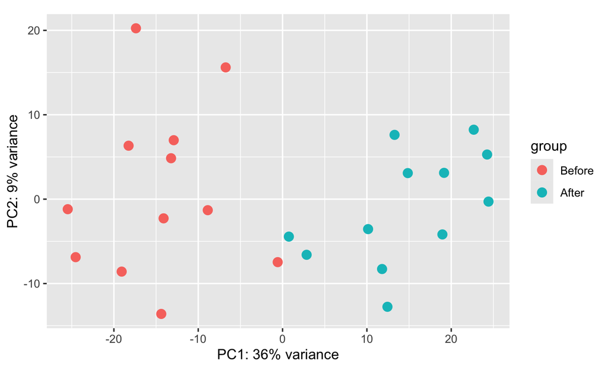

```r
# Method 2: : ---------------------------------
# more customizable

# 1. Compute PCA
pca <- prcomp(t(assay(dds.vst)))

# 2. Compute contribution of each component to the total variance
percentVar <- pca$sdev^2 / sum( pca$sdev^2)
pc1 <- round(percentVar*100, digits = 1)[1]
pc2 <- round(percentVar*100, digits = 1)[2]

# 3. assembly the data for the plot
pca.df <- data.frame(PC1=pca$x[,"PC1"],
                   PC2=pca$x[,"PC2"],
                   Treatment=dds.vst@colData$Treatment,
                   Subject_id=dds.vst@colData$Sbj_id
                   )

# 4. Generate plot
pca.p <- ggplot(data=pca.df, aes(x=PC1, y=PC2, color=Subject_id, shape=Treatment)) +
    geom_point(size=3) +
    xlab(paste0("PC1:",pc1,"% variance")) +
    ylab(paste0("PC2:",pc2,"% variance"))

# 5. Save PCA plot
ggsave(filename = "pca.pdf", plot = pca.p)
```

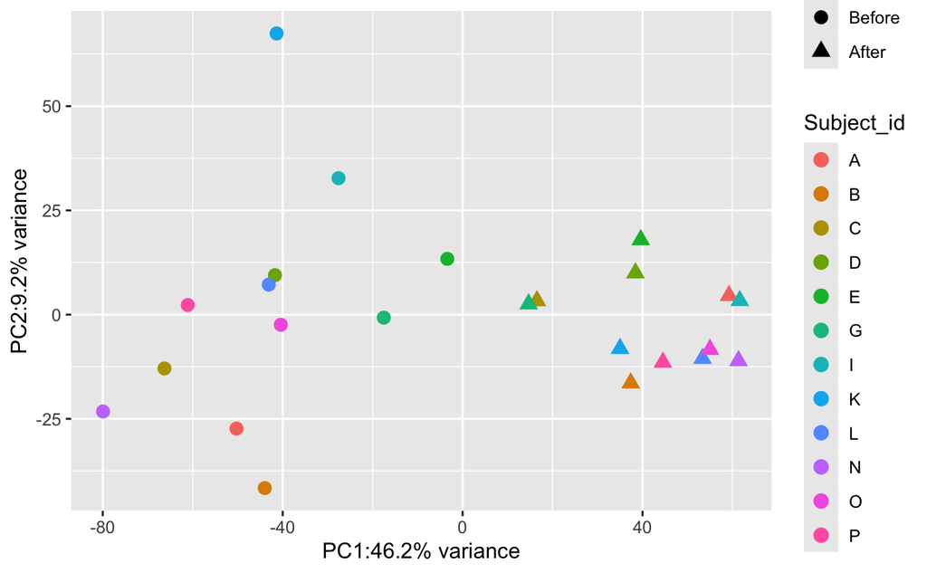

```r
pca.p
```

# G. Run differential expression

We will contrast *`After`* vs *`Before`* factors of the *`Treatment`* variable, controlling by subject (paired experimental design).

```r
# 1. Add design formula: After vs Before, within subjects
design(dds) <- ~Sbj_id + Treatment

# 2. Recompute dispersions
dds <- DESeq(dds)
```

```
found already estimated dispersions, replacing these
```

```r
# 3. Print out coeficients
resultsNames(dds)
```

```
 [1] "Intercept"                 "Sbj_id_B_vs_A"             "Sbj_id_C_vs_A"
 [4] "Sbj_id_D_vs_A"             "Sbj_id_E_vs_A"             "Sbj_id_G_vs_A"
 [7] "Sbj_id_I_vs_A"             "Sbj_id_K_vs_A"             "Sbj_id_L_vs_A"
[10] "Sbj_id_N_vs_A"             "Sbj_id_O_vs_A"             "Sbj_id_P_vs_A"
[13] "Treatment_After_vs_Before"
```

```r
# 4. Get DE results ------------------------------------------------

# 4.2 Method 2: Using coeficients
res.2 <- lfcShrink(dds, contrast=list("Treatment_After_vs_Before"), type = "ashr")
```

```
using 'ashr' for LFC shrinkage. If used in published research, please cite:
    Stephens, M. (2016) False discovery rates: a new deal. Biostatistics, 18:2.
    https://doi.org/10.1093/biostatistics/kxw041
```

```r
summary(res.2, alpha=0.05)
```

```
out of 18818 with nonzero total read count
adjusted p-value < 0.05
LFC > 0 (up)       : 6480, 34%
LFC < 0 (down)     : 6781, 36%
outliers [1]       : 0, 0%
low counts [2]     : 0, 0%
(mean count < 4)
[1] see 'cooksCutoff' argument of ?results
[2] see 'independentFiltering' argument of ?results
```

Next, we will contrast *`After`* vs *`Before`* factors of the *`Treatment`* variable, but this time without controlling by subject.

```r
# 1. Add design formula: After vs Before, within subjects
design(dds) <- ~Treatment

# 2. Recompute dispersions
dds <- DESeq(dds)
```

```
found already estimated dispersions, replacing these
-- replacing outliers and refitting for 36 genes
-- DESeq argument 'minReplicatesForReplace' = 7
-- original counts are preserved in counts(dds)
```

```r
# 3. Print out coeficients
resultsNames(dds)
```

```
[1] "Intercept"                 "Treatment_After_vs_Before"
```

```r
# 4. Get DE results ------------------------------------------------

# 4.2 Method 2: Using coeficients
res.3 <- lfcShrink(dds, contrast=list("Treatment_After_vs_Before"), type = "ashr")
```

```
using 'ashr' for LFC shrinkage. If used in published research, please cite:
    Stephens, M. (2016) False discovery rates: a new deal. Biostatistics, 18:2.
    https://doi.org/10.1093/biostatistics/kxw041
```

```r
summary(res.3, alpha=0.05)
```

```
out of 18818 with nonzero total read count
adjusted p-value < 0.05
LFC > 0 (up)       : 6130, 33%
LFC < 0 (down)     : 6422, 34%
outliers [1]       : 0, 0%
low counts [2]     : 0, 0%
(mean count < 3)
[1] see 'cooksCutoff' argument of ?results
[2] see 'independentFiltering' argument of ?results
```

**Note:** Usually, sensitivity drops when a paired experiment is analyzed unpaired.

# H. Looking at the effect of the genotype on how genes respond to treatment: Interactions

Now the main effect (what we are interested in) is the interaction term (Genotype:Treatment), that has to be at the end of the design formula.

The second most important effect is the Treatment (Before/After) that will be the X axis, followed by the Genotype and the Subj_id:

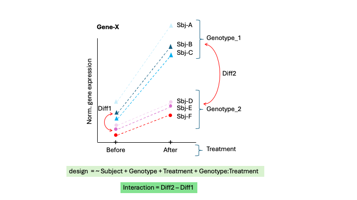

Example of a hypothetical gene that is differentially expressed across treatments and that responds differently depending on the genotype.

Note the **nested** design:

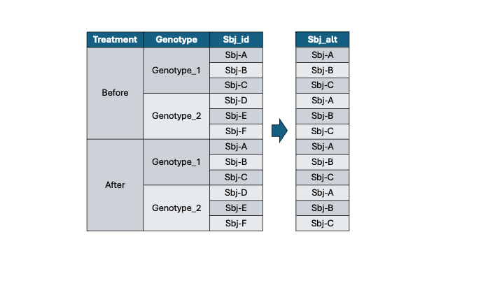

Nested design: each level of downstream variable has to be represented within each level of the upstream variable. To fulfill this DESeq requirement, Sbj_id levels have to be transformed into Sbj_alt values.

```r
res.inte <- results(dds, contrast=list("GenotypeGeno_2.TreatmentAfter"))

summary(res.inte, alpha=0.05)
```

[output not shown]

[output not shown]

```
out of 18818 with nonzero total read count
adjusted p-value < 0.05
LFC > 0 (up)       : 982, 5.2%
LFC < 0 (down)     : 1052, 5.6%
outliers [1]       : 0, 0%
low counts [2]     : 2189, 12%
(mean count < 12)
[1] see 'cooksCutoff' argument of ?results
[2] see 'independentFiltering' argument of ?results
```

Plot an example of a deferentially expressed gene with a significant interaction.

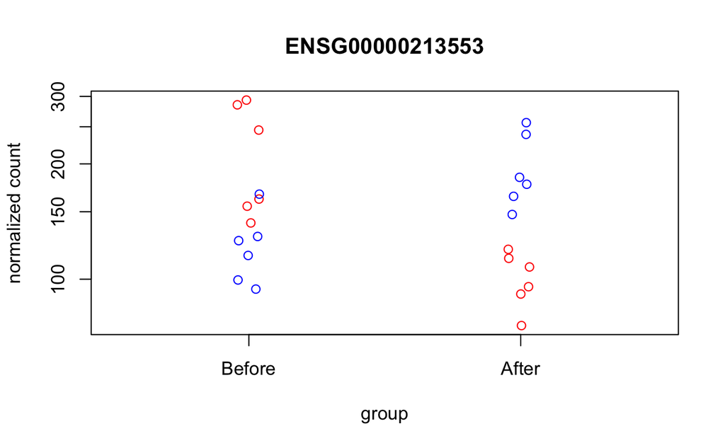

```r
# Plot an example of interaction
gene <- "ENSG00000213553"
plotCounts(dds = dds,
               gene = gene,
               intgroup = c("Treatment"),
               returnData = FALSE,
               col=c("red","blue")[dds@colData$Genotype])
```

Now let’s find out genes that are deferentially expressed in Genotype `Geno_1`.

```r
res.geno_1.coef <- lfcShrink(dds, contrast=list("Treatment_After_vs_Before"), type = "ashr")
```

```
using 'ashr' for LFC shrinkage. If used in published research, please cite:
    Stephens, M. (2016) False discovery rates: a new deal. Biostatistics, 18:2.
    https://doi.org/10.1093/biostatistics/kxw041
```

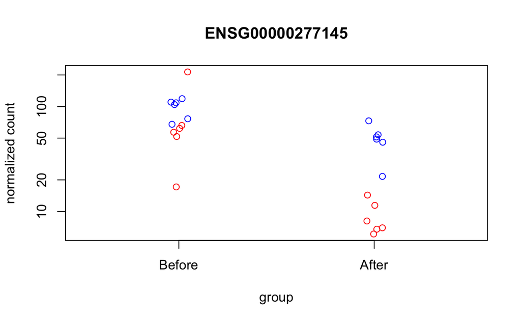

```r
# Plot an example of interaction
gene <- "ENSG00000277145"
plotCounts(dds = dds,
               gene = gene,
               intgroup = c("Treatment"),
               returnData = FALSE,
               col=c("red","blue")[dds@colData$Genotype])
```

What genes are deferentially expressed across Treatmeent in Genotype `Geno_2`.

```r
# 4. Get DE results ------------------------------------------------

# 4.2 Method 2: Using coeficients
res.geno_2 <- lfcShrink(dds, contrast=list("Treatment_After_vs_Before", "GenotypeGeno_2.TreatmentAfter"), type = "ashr")
```

```
using 'ashr' for LFC shrinkage. If used in published research, please cite:
    Stephens, M. (2016) False discovery rates: a new deal. Biostatistics, 18:2.
    https://doi.org/10.1093/biostatistics/kxw041
```

```r
summary(res.geno_2, alpha=0.05)
```

```
out of 18818 with nonzero total read count
adjusted p-value < 0.05
LFC > 0 (up)       : 592, 3.1%
LFC < 0 (down)     : 979, 5.2%
outliers [1]       : 0, 0%
low counts [2]     : 4014, 21%
(mean count < 24)
[1] see 'cooksCutoff' argument of ?results
[2] see 'independentFiltering' argument of ?results
```

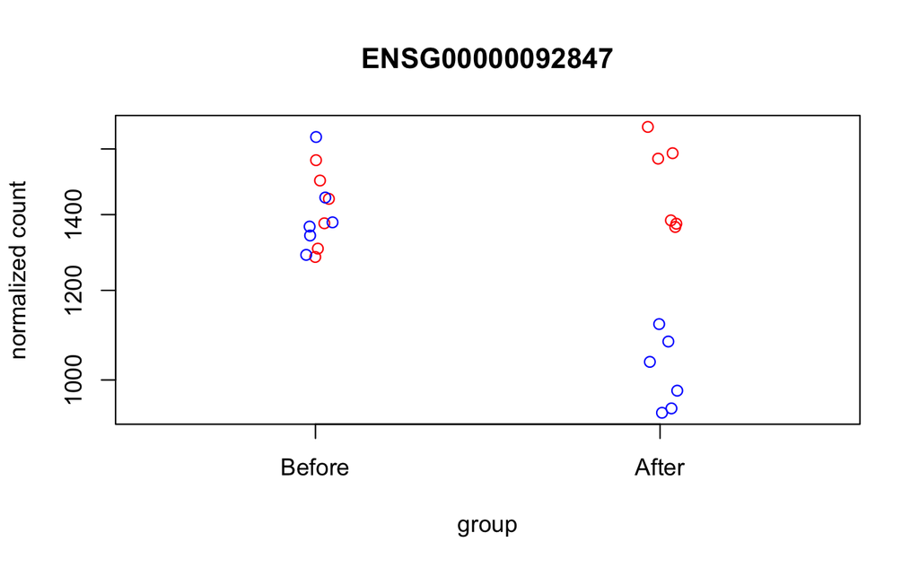

```r
# Plot an example of interaction
gene <- "ENSG00000092847"
plotCounts(dds = dds,
               gene = gene,
               intgroup = c("Treatment"),
               returnData = FALSE,
               col=c("red","blue")[dds@colData$Genotype])
```